# 天鳳位のデータ分析

菊池大智

2021/1/21

```r
library(ggplot2)
```

## 1.はじめに

麻雀に興味があり、ネット麻雀の最高峰と呼ばれる「天鳳」でトップある「天鳳位」の打ち方について分析をしたい

## 2.仮説

麻雀はトップを目指してラスを回避するものである。 トップになるためには「和了素点」が重要で、ラスにならないためには「放銃素点」が重要であると考える

## 3.問題の背景

天鳳には30万人弱のプレイヤーが活動しているが天鳳位になっているのは20名とごく一部のプレイヤーである。 天鳳位である20名のうちデータを公開している15名のプレイヤーについて考えたい

## 4.分析

#### 分析の方法

トップ率とラス率に関係する関数を回帰分析で探す。

#### データの紹介

今回使用するデータとして天鳳牌譜データが公開されている15名の天鳳位の成績データを使用します。 （ASAPIN、（≧▽≦）、独歩、すずめクレイジー、太くないお、タケオしゃん、コーラ下さい、かにマジン、就活生@川村軍団、ウルトラ立直、トトリ先生19歳、おかもと、gousi、お知らせ、右折するひつじ。また、トトリ先生19歳はASAPINのサブアカウント、右折するひつじはおかもとのサブアカウントです。）また、部屋は鳳凰卓のみ、ルールは東南戦(喰アリ赤アリ)を対象としています。

## 5.分析の結果 考察

### 分析

#### トップ率と和了素点の回帰分析

```r
data1<-read.csv("Tenhoui_data.csv")

top1<-lm(top~horasoten,data=data1)
summary(top1)
```

```
##
## Call:
## lm(formula = top ~ horasoten, data = data1)
##
## Residuals:
##       Min        1Q    Median        3Q       Max
## -0.024236 -0.005498  0.001426  0.007646  0.016594
##
## Coefficients:
##               Estimate Std. Error t value Pr(>|t|)
## (Intercept)  4.611e-01  1.292e-01   3.569  0.00343 **
## horasoten   -3.331e-05  2.296e-05  -1.451  0.17056
## ---
## Signif. codes:  0 '***' 0.001 '**' 0.01 '*' 0.05 '.' 0.1 ' ' 1
##
## Residual standard error: 0.01167 on 13 degrees of freedom
## Multiple R-squared:  0.1393, Adjusted R-squared:  0.07313
## F-statistic: 2.105 on 1 and 13 DF,  p-value: 0.1706
```

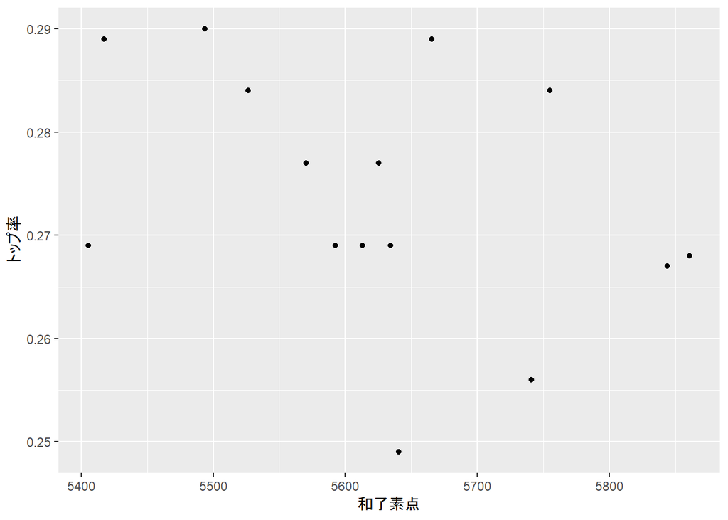

```r
ggplot(data=data1)+
  geom_point(aes(x=horasoten,y=top))+
  xlab("和了素点")+
  ylab("トップ率")
```

#### トップ率と和了率の回帰分析

```r
top2<-lm(top~horaritu,data=data1)
summary(top2)
```

```
##
## Call:
## lm(formula = top ~ horaritu, data = data1)
##
## Residuals:
##        Min         1Q     Median         3Q        Max
## -0.0107227 -0.0055042 -0.0000141  0.0053832  0.0134561
##
## Coefficients:
##             Estimate Std. Error t value Pr(>|t|)
## (Intercept) -0.02805    0.06369   -0.44 0.666935
## horaritu     1.39073    0.29338    4.74 0.000386 ***
## ---
## Signif. codes:  0 '***' 0.001 '**' 0.01 '*' 0.05 '.' 0.1 ' ' 1
##
## Residual standard error: 0.007615 on 13 degrees of freedom
## Multiple R-squared:  0.6335, Adjusted R-squared:  0.6053
## F-statistic: 22.47 on 1 and 13 DF,  p-value: 0.0003861
```

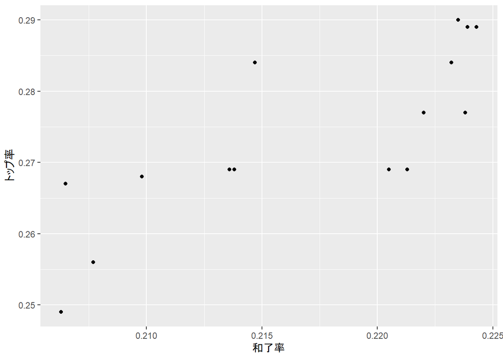

```r
ggplot(data=data1)+
  geom_point(aes(x=horaritu,y=top))+
  xlab("和了率")+
  ylab("トップ率")
```

#### ラス率と放銃素点の回帰分析

```r
last1<-lm(las~houjusoten,data=data1)
summary(last1)
```

```
##
## Call:
## lm(formula = las ~ houjusoten, data = data1)
##
## Residuals:
##       Min        1Q    Median        3Q       Max
## -0.015144 -0.006396  0.001470  0.004198  0.019386
##
## Coefficients:
##               Estimate Std. Error t value Pr(>|t|)
## (Intercept)  5.001e-02  1.217e-01   0.411    0.688
## houjusoten  -3.437e-05  2.488e-05  -1.381    0.190
##
## Residual standard error: 0.009909 on 13 degrees of freedom
## Multiple R-squared:  0.128,  Adjusted R-squared:  0.06089
## F-statistic: 1.908 on 1 and 13 DF,  p-value: 0.1905
```

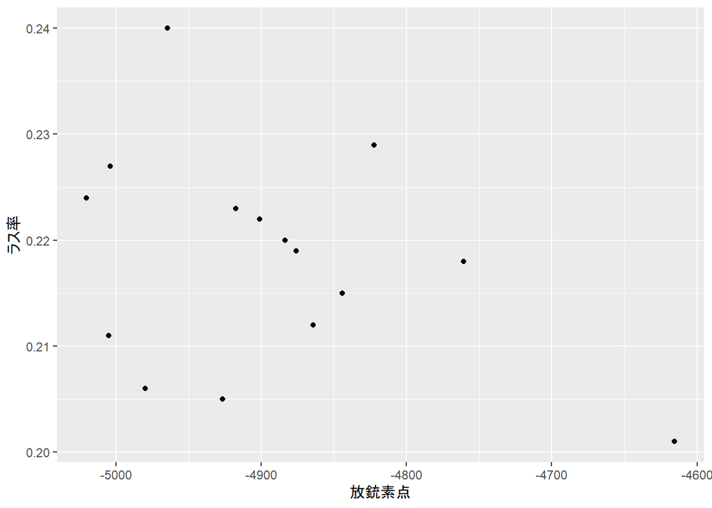

```r
ggplot(data=data1)+
  geom_point(aes(x=houjusoten,y=las))+
  xlab("放銃素点")+
  ylab("ラス率")
```

#### ラス率と放銃率の回帰分析

```r
last2<-lm(las~houjuritu,data=data1)
summary(last2)
```

```
##
## Call:
## lm(formula = las ~ houjuritu, data = data1)
##
## Residuals:
##       Min        1Q    Median        3Q       Max
## -0.012629 -0.004698  0.002357  0.004858  0.008709
##
## Coefficients:
##             Estimate Std. Error t value Pr(>|t|)
## (Intercept)  0.10725    0.02606   4.116 0.001217 **
## houjuritu    0.94580    0.22177   4.265 0.000922 ***
## ---
## Signif. codes:  0 '***' 0.001 '**' 0.01 '*' 0.05 '.' 0.1 ' ' 1
##
## Residual standard error: 0.006851 on 13 degrees of freedom
## Multiple R-squared:  0.5832, Adjusted R-squared:  0.5511
## F-statistic: 18.19 on 1 and 13 DF,  p-value: 0.0009215
```

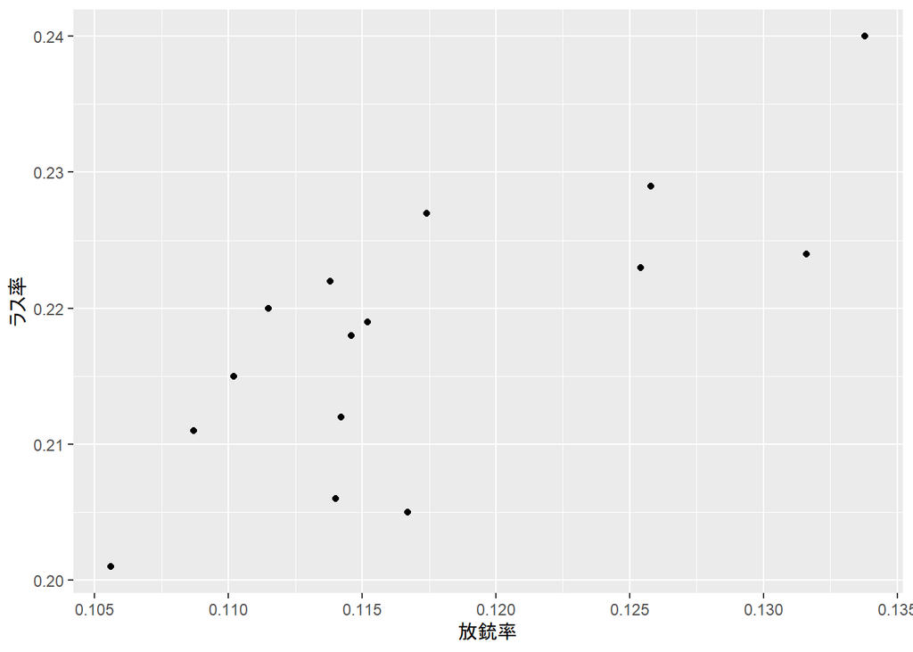

```r
ggplot(data=data1)+
  geom_point(aes(x=houjuritu,y=las))+
  xlab("放銃率")+
  ylab("ラス率")
```

### 考察

トップになるためには和了素点は関係なく和了率が関係していることから、和了重視の打ち方が良いことがわかった。また、ラスを回避するには放銃素点は関係なく放銃率が関係していることから放銃しない打ち方が良いことがわかった。この二つのことを考えるとデジタルの守備型で打つ麻雀が良いと考える。

## 6.参考文献

https://tenhou.net/ranking.html